# Machine Learning

### Lecture 5: Linear Classification: SVM

## Learning Outcomes

- Recall Linear Regression
- Derive optimization problem for SVM
- Understand what is a support vector
- Understand what is a kernel and a kernel trick

# Binary Linear Classification

#### Training Dataset:

$$ \mathcal{D} = \{x_n, y_n\}_{n=1}^N, y_n \in \{-1, 1\} $$

#### Model:

$$ a(x_n) = sign(\langle w, x_n\rangle) $$

#### Cost function:

$$ \mathcal{L}(a, X) = \frac{1}{N}\sum_{n=1}^N \left[a(x_n) \neq y_n \right] = \frac{1}{N}\sum_{n=1}^N \left[M_n < 0 \right] ,\\ M_n = y_n \langle w, x_n\rangle $$

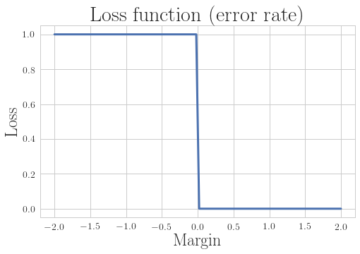

```python
plt.title('Loss function (error rate)')
plt.xlabel('Margin')
plt.ylabel('Loss')

plt.plot(x_grid, step(x_grid));
```

$$ 0 \leq \frac{1}{N}\sum_{n=1}^N \left[M_n < 0 \right] \leq \frac{1}{N}\sum_{n=1}^N \widetilde{L}(a, x_n) \rightarrow \min $$

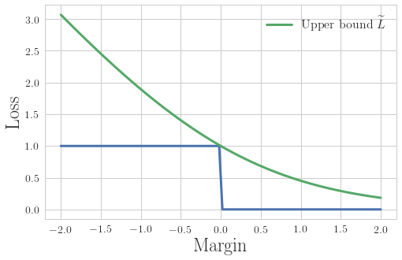

```python
plt.xlabel('Margin')
plt.ylabel('Loss')

plt.plot(x_grid, step(x_grid));
plt.plot(x_grid, logistic(x_grid), label=r'Upper bound $\widetilde{L}$');

plt.legend(fontsize=16);
```

Different upper bounds lead to models with different properties

- Logistic loss $\quad \Rightarrow \quad$ Logistic Regression
- Hinge Loss + $L_2$ regularization $\quad \Rightarrow\quad$ Linear SVM

Can we go other way around? From properties to upper bound.

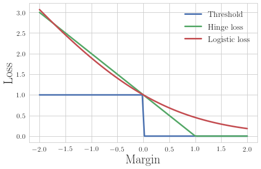

```python
plt.xlabel('Margin')
plt.ylabel('Loss')
plt.plot(x_grid, step(x_grid), label='Threshold');
plt.plot(x_grid, hinge(x_grid), label='Hinge loss');
plt.plot(x_grid, logistic(x_grid), label='Logistic loss');
plt.legend(fontsize=16);
```

## Logistic Regression

#### Training Dataset: $\quad \mathbb{Y} = \{-1, 1\}$

#### Model: $\quad \quad \quad \quad a(X) = \text{sign}(\langle w, x \rangle)$

How to change the model, so that we have **probabilities** as an output?

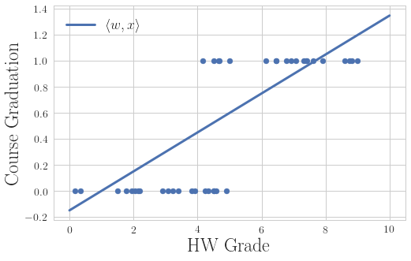

```python
plt.xlabel('HW Grade')
plt.ylabel('Course Graduation')
plt.scatter(x, y);
plt.plot(x_grid, -.15 + 0.15*x_grid, label=r'$\langle w, x \rangle$');
plt.legend(fontsize=18);
```

Let's convert outputs $\langle w, x \rangle$ to [0, 1] with sigmoid:

$$ \sigma(x) = \frac{1}{1 + \exp(-x)} $$

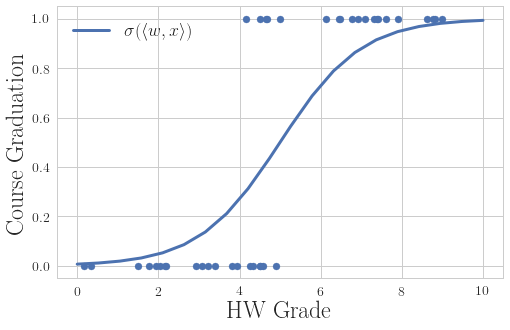

```python
plt.xlabel('HW Grade')
plt.ylabel('Course Graduation')
plt.scatter(x, y);
plt.plot(x_grid, sigmoid(-5 + 1*x_grid), label=r'$\sigma(\langle w, x \rangle)$');
plt.legend(fontsize=18);
```

## Traning Logisitc Regression

- We define probability of a positive class as

$$ \mathbb{P}(y_n = 1) = \sigma(\langle w, x_n\rangle ) $$

- Maximum likelihood

$$ \log \prod_n p(y_n) \rightarrow \max_{w} $$

- Final objective

$$ \mathcal{L} = \sum_{n} \log (1 + \exp( - y_n \langle w, x_n \rangle )) \rightarrow \min_w $$

# Supprot Vector Machine

### Upper bound approach

- Hinge loss

$$ \left[M_n(w) < 0 \right] \leq \max \left(0, 1 - M_n(w)\right) $$

- and $L_2$ regularization

$$ \mathcal{L} = \max \left(0, 1 - M_n(w)\right) + \frac{1}{2C}\|w\|^2 \rightarrow \min_w $$

### How to choose the best classifier

### Definitions

- Linear Classifier defines a hyperplane:

$$\langle w, x \rangle = 0$$

- Distance from $x^*$ to this hyperplane:

$$\frac{|\langle w, x^* \rangle|}{\|w\|} $$

### Step 1. Linearly Separable Case (Hard Margin)

We can perfectly classify all the points: $$ M_n(w) > 0 \, \forall n $$

#### Margin of a classifier - the wider the better

## Goal

- Maximal Margin
- No erros

## Goal

- Maximal Margin

$$ \max_w \left( 2 \min_n \frac{|\langle x_n, w \rangle|}{\|w\|} \right) $$

- No erros

$$ M_n(w) > 0\, \forall n $$

Let's normalize the weights by $\min_n |\langle x_n, w \rangle|$.

Namely, $w^{new} = \frac{w}{\min_n |\langle x_n, w \rangle|}\,\, \Rightarrow \,\, \min_n |\langle w^{new}, x_n \rangle| = 1$

Why can we do that?

## Goal

- Maximal Margin

$$ \frac{2}{\|w\|} \rightarrow \max_w $$

- No erros

$$ M_n(w) > 0\, \forall n $$

- Normalization

$$ \min_n |\langle w, x_n \rangle| = 1 $$

## Goal

- Maximal Margin

$$ \max_w \frac{2}{\|w\|} $$

- No erros + Normalization

$$ y_n \langle w, x_n \rangle \geq 1 \, \forall n $$

## Hard Margin SVM

\begin{equation} \begin{cases} \min_w \frac{1}{2}\|w\| \\ M_n(w) \geq 1 \end{cases} \end{equation}

### Step 2. Soft Margin

Let's soften the restrictions. We introduce auxilary **slack** variables $\xi_n$:

\begin{equation} \begin{cases} \min_{x, \xi_n} \frac{1}{2}\|w\| + C \sum_n \color{red}{\xi_n}\\ M_n(w) \geq 1 - \color{red}{\xi_n}\\ \color{red}{\xi_n} \geq 0 \end{cases} \end{equation}

- $\xi$ controls how "hard" we violate the constraint
- We need to penalize for these violations

\begin{cases} \min_{x, \xi_n} \frac{1}{2}\|w\| + C \sum_n \xi_n\\ \xi_n \geq \max(0, 1 - M_n(w)) \\ \end{cases}

Equivalent unconditional optimization task

$$ \min_w \left( \frac{1}{2}\|w\| + C \sum_n \max(0, 1 - M_n(w))\right) $$

\begin{equation} \begin{cases} \min_{x, \xi_n} \frac{1}{2}\|w\| + C \sum_n \xi_n\\ M_n(w) \geq 1 - \xi_n\\ \xi_n \geq 0 \end{cases} \end{equation}

### Karush-Kunh-Tucker condition

\begin{equation} \begin{cases} \min f(x) \\ g_i (x) \leq 0 \end{cases} \end{equation}

If $x$ is a local minimum, $\exists \, \mu_i$:

\begin{equation} \begin{cases} \frac{\partial \mathcal{L}}{\partial x} = 0\\ g_i (x) \leq 0 \\ \mu_i \geq 0 \\ \mu_i g_i(x) = 0 \end{cases} , \,\text{where} \quad \mathcal{L} = f(x) + \sum_i \mu_i g_i(x) \end{equation}

### KKT for SVM

\begin{equation} \begin{cases} w = \sum_n \lambda_n y_n x_n, \quad \nu_n + \lambda_n = C \\ M_n(w) \geq 1 - \xi_n \\ \lambda_n \geq 0, \nu_n \geq 0, \xi_n \geq 0 \\ \lambda_n (1 - \xi_n - M_n(w)) = 0 \\ \nu_n \xi_n = 0 \\ \end{cases} \end{equation}

Types of objects depending on $\lambda_n$

- If $\lambda_n = 0$. This object does not "participate" in the solution:
  - $\nu_n = C$
  - $\xi = 0$
  - $M_n(w) \geq 1$

### KKT for SVM

\begin{equation} \begin{cases} w = \sum_n \lambda_n y_n x_n, \quad \nu_n + \lambda_n = C \\ M_n(w) \geq 1 - \xi_n \\ \lambda_n \geq 0, \nu_n \geq 0, \xi_n \geq 0 \\ \lambda_n (1 - \xi_n - M_n(w)) = 0 \\ \nu_n \xi_n = 0 \\ \end{cases} \end{equation}

Types of objects depending on $\lambda_n$

- If $\lambda_n = 0$. This object does not "participate" in the solution:
- If $\lambda_n \in (0, C)$. This is a **support vector**, which lies on the border:
  - $\nu_n \in (0, C)$ and $1 - \xi_n - M_n(w) = 0$
  - $\xi_n = 0$
  - $M_n(w) = 1$

### KKT for SVM

\begin{equation} \begin{cases} w = \sum_n \lambda_n y_n x_n, \quad \nu_n + \lambda_n = C \\ M_n(w) \geq 1 - \xi_n \\ \lambda_n \geq 0, \nu_n \geq 0, \xi_n \geq 0 \\ \lambda_n (1 - \xi_n - M_n(w)) = 0 \\ \nu_n \xi_n = 0 \\ \end{cases} \end{equation}

Types of objects depending on $\lambda_n$

- If $\lambda_n = 0$. This object does not "participate" in the solution
- If $\lambda_n \in (0, C)$. This is a **support vector**, which lies on the border
- If $\lambda_n = C$. This is a **support vetor**, which lies inside the border (or on the wrong side):
  - $\nu_n = 0$ and $1 - \xi_n - M_n(w) = 0$
  - $\xi_n > 0$
  - $M_n(w) < 1$

### Dual Problem

$$ \begin{cases} - \mathcal{L} = - \sum_n \lambda_n + \frac12 \sum_n \sum_m \lambda_n \lambda_m y_m y_n\langle x_n, x_m \rangle \rightarrow \min_{\lambda}\\ 0 \leq \lambda_n \leq C \end{cases} $$

where $$ w = \sum_n \lambda_n y_n x_n $$

Therefore, the resulting classifier is:

$$ a(x) = \text{sign} \left(\sum_n \lambda_n y_n \langle x, x_n\rangle \right) $$

### Dual Problem

$$ \begin{cases} - \mathcal{L} = - \sum_n \lambda_n + \frac12 \sum_n \sum_m \lambda_n \lambda_m y_m y_n \color{red}{\langle x_n, x_m \rangle} \rightarrow \min_{\lambda}\\ 0 \leq \lambda_n \leq C \end{cases} $$

where $$ w = \sum_n \lambda_n y_n x_n $$

Therefore, the resulting classifier is:

$$ a(x) = \text{sign} \left(\sum_n \lambda_n y_n \color{red}{\langle x, x_n\rangle} \right) $$

### Kernel Trick

- Can we take an arbitrary function $K(x, x^{'})$ and use it instead of $\langle x, x^{'}\rangle$ in SVM formulation?
- Yes! But...
- But $K(x, x^{'})$ should be a kernel

aka there should be some space, in which $K(x, x^{'})$ is a scalar product. Namely,

$$\exists \psi, s.t. K(x, x^{'}) = \langle \psi(x), \psi(x^{'})\rangle$$

- Good news: we do not have to know much about this space
- Bad news: we need to ensure that $K$ is indeed a kernel

### Constructing a kernel

What **is** a kernel:

- $K(x, x^{'}) = \langle x, x^{'}\rangle$
- Constant: $K(x, x^{'}) = 1$
- Product of 2 kernels: $K(x, x^{'}) = K_1(x, x^{'})K_2(x, x^{'})$
- Weighted sum: $K(x, x^{'}) = \alpha_1 K_1(x, x^{'}) + \alpha_2 K_2(x, x^{'}), \alpha_1, \alpha_2 > 0$

### Kernel example

Consider the following kernel:

$$ K(a, b) = \langle a, b\rangle ^2, a, b \in \mathbb{R}^2 $$

Let's open the brackes $$ K(a, b) = \langle (a_1^2, a_2^2, \sqrt{2} a_1 a_2), (b_1^2, b_2^2, \sqrt{2} b_1 b_2)\rangle ^2 $$

That is

$$\psi(a) = (a_1^2, a_2^2, \sqrt{2} a_1 a_2)$$

### Examples of kernels

- Polynomial kernel

$$K(x, x^{'}) = \langle x, x^{'}\rangle^d $$

or

$$K(x, x^{'}) = \langle x, x^{'} + 1\rangle^d $$

- Radial basis functions

$$K(x, x^{'}) = \exp(-\gamma \|x - x^{'}\|) $$

### Kernel SVM

$$ a(x) = \text{sign} \left(\sum_n \lambda_n y_n \color{red}{K(x, x_n)} \right) $$

## Learning Outcomes

- Recall Linear Regression
- Derive optimization problem for SVM
- Understand what is a support vector
- Understand what is a kernel and a kernel trick